# Analyzing MLB Swing Outcomes with Statcast Pitch-by-Pitch Data

How Bat Speed, Launch Angle, and Pitch Characteristics Drive Offensive Production

**⚾ Introduction**

Live Pitch Type Cycle: **Fastballs**

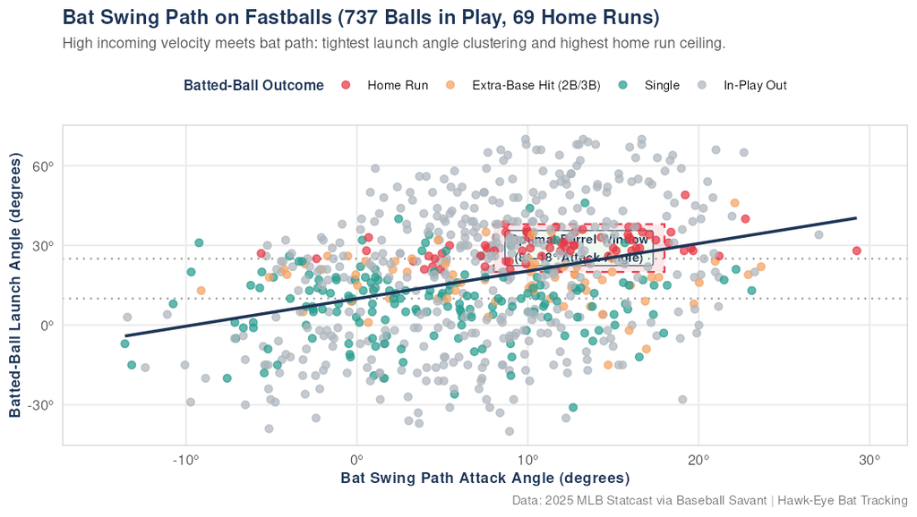

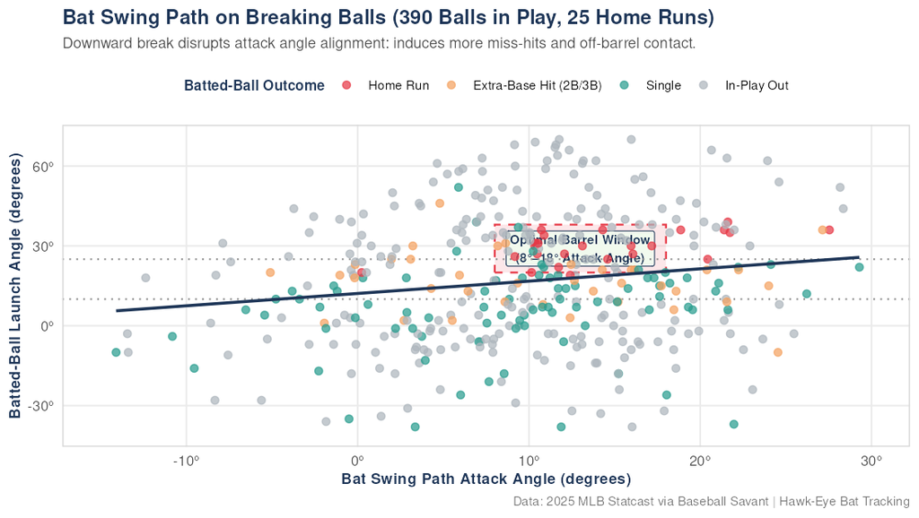

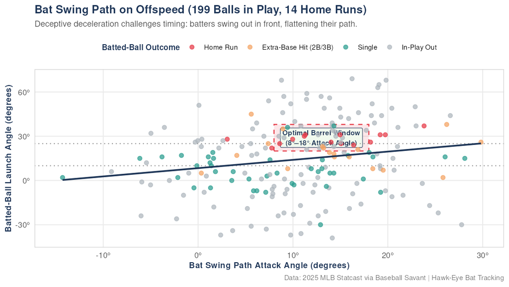

Data automatically cycles pitch types every 6 seconds. Click any button above to pause on a specific pitch type. **Statcast 2025**

Modern Major League Baseball analytics has been revolutionized by Hawk-Eye optical tracking and bat-sensor Statcast data provided through **Baseball Savant**. While traditional metrics focused solely on pitch velocity and movement, newly available swing-tracking technology captures the 3D trajectory of the bat barrel through the hitting zone. **This project is specifically focused on how a hitter’s bat swing path—in particular, their vertical attack angle and swing plane through the zone—shapes contact quality and dictates batted-ball outcomes.**

A hitter’s swing path is the fundamental blueprint for ball flight. A swing path that is too steep or too flat frequently leads to rolled-over ground balls or weak pop-ups. Conversely, an optimized bat path that closely mirrors the downward approach angle of incoming pitches creates a wider window of square contact, driving balls into the line-drive and high-value “barrel” zones. In this project, I examine how bat swing path metrics interact with pitch characteristics to produce outs, singles, extra-base hits, and home runs across elite MLB batters.

**ImportantCore Research Question**

How does a hitter’s **bat swing path** (specifically their vertical attack angle) interact with pitch type to shape **launch angle** and **exit velocity**, and what swing paths consistently maximize extra-base hits and home runs?

**📊 Data & Variables**

The data for this analysis comes from **MLB Statcast** via Baseball Savant, where each observation represents an individual pitch put into play. Below is a summary of the core variables I use to model and explain swing outcomes:

| Variable | Statcast Column | Units / Categories | Role in Analysis |
| --- | --- | --- | --- |
| **Attack Angle (Bat Path)** | `attack_angle` | Degrees ($-15^\circ\text{ to }30^\circ$) | Vertical path of the bat barrel at contact |
| **Exit Velocity** | `launch_speed` | mph ($60\text{--}118\text{ mph}$) | Measures raw contact hardness off the bat |
| **Launch Angle** | `launch_angle` | Degrees ($-45^\circ\text{ to }75^\circ$) | Determines trajectory (grounder, liner, fly ball) |
| **Bat Speed** | `bat_speed` | mph ($60\text{--}85\text{ mph}$) | Captures batter swing effort at the sweet spot |
| **Pitch Type** | `pitch_type` | Fastball, Slider, Changeup, Curveball | Accounts for movement profile and deception |
| **Release Velocity** | `release_speed` | mph ($75\text{--}102\text{ mph}$) | Measures incoming pitch speed out of the hand |

**Why These Variables Matter Together:**

- **Bat Path Attack Angle (`attack_angle`):** Dictates how cleanly the barrel plane matches the downward flight of the pitch. An upward path of $8^\circ\text{--}18^\circ$ maximizes line-drive and extra-base hit launch angles.
- **Exit Velocity (`launch_speed`) & Launch Angle (`launch_angle`):** Higher exit velocities give fielders less time to react and carry the ball farther, but hard contact hit straight into the ground ($< 5^\circ$) often results in an out. Pairing $98+\text{ mph}$ exit velocity with an optimal launch angle ($24^\circ\text{--}38^\circ$) defines the **Barrel Zone**, where home runs are most frequent.
- **Bat Speed (`bat_speed`):** Introduced in recent Statcast tracking, bat speed separates a batter’s raw swing effort from point-of-contact quality.
- **Pitch Type (`pitch_type`) & Release Velocity (`release_speed`):** Fastballs provide incoming kinetic energy that can boost exit velocity when squared up, whereas breaking and offspeed pitches disrupt timing and induce weaker launch angles.

**📈 League Visualization**

**Reading the Chart:** Each point below represents a batted ball in play. Notice how **Home Runs** (red) cluster tightly inside the shaded **Barrel Zone**, while **Singles** (teal) form a low-trajectory line-drive band between $5^\circ$ and $22^\circ$.

[figure not shown]

### Key Insights from the League-Wide Batted-Ball Distribution

- **The Power of the Barrel Zone ($24^\circ\text{--}38^\circ$, $98+\text{ mph}$):** Notice the tight cluster of red **Home Runs** concentrated inside the shaded rectangle. Balls struck with both elite exit velocity and an optimal launch angle produce an expected slugging percentage near $2.000$, resulting in nearly all home run production in the 2025 dataset.
- **Line Drives Drive Batting Average ($10^\circ\text{--}25^\circ$):** The teal points (**Singles**) and orange points (**Extra-Base Hits**) dominate this corridor. Line drives regularly travel over the heads of the infielders while landing in the gaps ahead of outfielders, maximizing on-base probability.
- **The Ground Ball Trap ($< 10^\circ$):** Even when a batter makes blisteringly hard contact ($100+\text{ mph}$) into the ground, turf friction and infielder positioning limit the outcome to in-play outs or routine singles. Downward contact almost never produces extra bases.
- **Pop-Ups and Ineffective Lift ($> 50^\circ$):** Regardless of how hard the ball is struck, balls launched at extreme upward angles hang in the air for 5+ seconds, allowing fielders to settle underneath them for routine outs ($> 98\%$ out rate).

**NoteTakeaway for Batter Approach**

Maximizing offensive production is not simply a matter of hitting the ball hard—it requires directing kinetic energy into the **$10^\circ\text{ to }35^\circ$ launch window** where ball flight physics and field dimensions yield the greatest offensive run expectancy.

**📖 Swing Story**

[figure not shown]

The static chart above shows that **swings meeting the ball on a `10°` to `20°` upward path generate by far the most destructive contact in baseball**. Inside the `10°–15°` and `15°–20°` bands, average exit velocity peaks at **`94.5 mph`**, barrel rates climb to **`15.6%–17.7%`**, extra-base hits jump to **`22.2%–24.0%`**, and hitters post a massive **`.531` to `.575` wOBA** on balls in play (`11.4%–14.6%` home runs). Outside that window, production falls off in two completely different ways: downward chops below `0°` beat the ball into the turf (`1.9°` average launch angle), yielding `32.6%` singles but an almost nonexistent **`0.9%` home run rate**, whereas overly steep uppercuts above `20°` slice underneath the baseball—causing average exit velocity to plunge nearly 9 mph to **`85.5 mph`** and barrels to collapse from `17.7%` down to **`5.7%`**.

[figure not shown]

The physics diagram above puts this sweet spot into context: because a pitcher releases the baseball from an elevated mound, nearly every fastball and breaking ball crosses home plate moving **downward at `6°` to `10°`**. A hitter whose barrel rises at **`10°` to `20°`** meets that descending pitch nearly head-on, keeping the sweet spot aligned with the ball’s path across a wider timing window instead of grazing it at a single point. That explains the distinct player archetypes in our dataset: power hitters **Aaron Judge (`11.0°` average attack angle, `.583` wOBA)** and **Kyle Stowers (`10.0°`, `.518` wOBA)** live right at the front door of the `10°–20°` damage zone, while **Bobby Witt Jr. (`5.2°`, `.422` wOBA)** intentionally trades loft (`4.6%` home runs per ball in play) for a flatter line-drive stroke that lets his elite bat speed (`74.6 mph`) and sprint speed turn hard grounders and low liners into extra bases.

**🔍 Player Exploration**

Use the dropdown menu below to inspect real **2025 Statcast swing outcomes** exported from Baseball Savant for four featured hitters: **Kyle Stowers**, **Adley Rutschman**, **Aaron Judge**, and **Bobby Witt Jr.**

⚾ Select a Hitter (2025 Season):

**Kyle Stowers — Miami Marlins (2025 Scouting Profile):** Power-oriented left-handed swing (74.9 mph avg bat speed, 25 HRs in 2025) with strong pull-side barrel production.

[figure not shown]

**Baseball Savant Stance & Bat-Path Breakdown — Kyle Stowers (`L/L`)**

- **Stance & Starting Bat Angle:** Sets up in a tall, slightly open left-handed stance ($\sim 14^\circ$ open) with his hands held high near the back shoulder. His bat starts at a steep vertical angle ($\sim 68^\circ$ above horizontal) with a subtle barrel tip toward the pitcher during his stride load, creating natural loft leverage.
- **Bat Path & Attack Angle:** Features an **Attack Angle** of **$10^\circ$** ($10.0^\circ$ on BIP, $10.6^\circ$ overall), an **Attack Direction** of **$+2.0^\circ$** (pull side), and a **Swing Path Tilt** of **$34.2^\circ$**. With a compact **Swing Length** of **$6.7\text{ ft}$** ($6.63\text{ ft}$ overall) and **$74.9\text{ mph}$** avg bat speed on contact ($73.0\text{ mph}$ overall, $25$ HRs), he matches the downward pitch plane flush to generate strong pull-side barrels and extra-base power.

[video not shown]

**Adley Rutschman — Baltimore Orioles (2025 Scouting Profile):** Switch-hitting catcher (69.8 mph avg bat speed, 6.9 ft compact swing length) with consistent line-drive contact.

[figure not shown]

**Baseball Savant Stance & Bat-Path Breakdown — Adley Rutschman (`S/R`)**

- **Stance & Starting Bat Angle:** As a switch-hitter, Rutschman uses a balanced, slightly wider base ($\sim 31\text{ in.}$ stance width) from both sides of the plate, staying slightly more open from the left side than the right. He starts with his bat resting at a relaxed, flatter setup angle ($\sim 45^\circ\text{--}50^\circ$) over his back shoulder, minimizing pre-pitch movement so his head stays still through pitch recognition.
- **Bat Path & Attack Angle:** Features an **Attack Angle** of **$8.6^\circ$** ($8^\circ$ in Savant 3D breakdown; $7^\circ$ RHB, $8.7^\circ$ overall), an **Attack Direction** of **$-0.5^\circ$** (centered spray), and a **Swing Path Tilt** of **$35.2^\circ$**. With a compact **Swing Length** of **$6.9\text{ ft}$** ($6.82\text{ ft}$ overall) and **$69.8\text{ mph}$** avg bat speed on contact ($68.1\text{ mph}$ overall, $12$ HRs), his path stays in the hitting zone exceptionally long for consistent line drives.

[video not shown]

[figure not shown]

**Baseball Savant Stance & Bat-Path Breakdown — Aaron Judge (`R/R`)**

- **Stance & Starting Bat Angle:** At $6'7''$, Judge uses a slightly closed-to-neutral stance ($\sim 5^\circ$ closed) with a controlled two-strike toe-tap gather. His bat begins nearly vertical ($\sim 75^\circ\text{--}80^\circ$ starting bat angle) high above his rear shoulder, allowing gravity and torso rotation to accelerate the barrel into the zone without over-striding.
- **Bat Path & Attack Angle:** Features an **Attack Angle** of **$11.0^\circ$** on contact ($14^\circ$ in Savant 3D tracking breakdown; $13.6^\circ$ overall), an **Attack Direction** of **$-3.7^\circ$** (power alley to dead center), and a steep **Swing Path Tilt** of **$38.4^\circ$**. His long **Swing Length** of **$8.0\text{ ft}$** paired with elite **$76.0\text{ mph}$** avg bat speed on contact ($74.8\text{ mph}$ overall, $55$ HRs, $95.1\text{ mph}$ avg exit velocity) produces league-leading barrel rates.

[video not shown]

**Bobby Witt Jr. — Kansas City Royals (2025 Scouting Profile):** Explosive 74.6 mph bat speed paired with a flat 5° attack angle that produces 543 balls in play and 26 home runs.

[figure not shown]

[video not shown]

**ℹ️ About**

### About Me

Hi, I’m **Ethan Katz**, a student at [New College of Florida](https://www.ncf.edu/) interested in data science, statistical modeling, and modern baseball analytics. This project was created using R, Quarto, and the tidyverse.

- **Name:** Ethan Katz
- **Email:** e.katz30@ncf.edu
- **GitHub Account:** github.com/ekatz30-debug
- **Final Project Repository:** https://github.com/ekatz30-debug/mlb-swing-outcomes
- **Institution:** [New College of Florida](https://www.ncf.edu/)

### Data Source

All pitch-level and bat-tracking data used in this project come from Major League Baseball’s Hawk-Eye optical tracking system via [Baseball Savant](https://baseballsavant.mlb.com/). Specifically, the 2025 pitch-by-pitch batted-ball dataset (`statcast_2025.csv`) was exported using [Statcast Search](https://baseballsavant.mlb.com/statcast_search), and the animated 3D swing-path and attack-angle visuals are sourced from Baseball Savant’s [Bat Tracking Swing Path & Attack Angle Leaderboard](https://baseballsavant.mlb.com/leaderboard/bat-tracking/swing-path-attack-angle).